# La Serena Data Science School 2017

# Loan Outcomes

Students: Daniela Grandon, Patricio Fibla, Tomas Muller, Ryan Keegan, Humna Awan

Group Name: **CaThruster**

Mentor: Pavlos Protopapas

[figure not shown]

## Problem Statement

Multiclass classification problem for predicting loan status from a rich dataset. The problem can be reduced to a classification problem to build a loan approval pre-check system for potential customers.

### Other Issues

The data available only covers a population which were already granted a loan, there is no data for the rejected population. In addition, there is missing data and many different features (~80) which we have to deal with.

## Data

```python
from pandas import DataFrame, read_csv
import matplotlib.pyplot as plt
import pandas as pd
import seaborn as sns
import numpy as np
%matplotlib inline

import os
currentDir= os.getcwd()
os.chdir(currentDir+'/../')


file = r'data/loan.csv'
loans = pd.read_csv(file)

sample = loans.loc[0:100]
sample
```

|  | id | member_id | loan_amnt | funded_amnt | funded_amnt_inv | term | int_rate | installment | grade | sub_grade | ... | total_bal_il | il_util | open_rv_12m | open_rv_24m | max_bal_bc | all_util | total_rev_hi_lim | inq_fi | total_cu_tl | inq_last_12m |
| --- | --- | --- | --- | --- | --- | --- | --- | --- | --- | --- | --- | --- | --- | --- | --- | --- | --- | --- | --- | --- | --- |
| 0 | 1077501 | 1296599 | 5000.0 | 5000.0 | 4975.000000 | 36 months | 10.65 | 162.87 | B | B2 | ... | NaN | NaN | NaN | NaN | NaN | NaN | NaN | NaN | NaN | NaN |
| 1 | 1077430 | 1314167 | 2500.0 | 2500.0 | 2500.000000 | 60 months | 15.27 | 59.83 | C | C4 | ... | NaN | NaN | NaN | NaN | NaN | NaN | NaN | NaN | NaN | NaN |
| 2 | 1077175 | 1313524 | 2400.0 | 2400.0 | 2400.000000 | 36 months | 15.96 | 84.33 | C | C5 | ... | NaN | NaN | NaN | NaN | NaN | NaN | NaN | NaN | NaN | NaN |
| 3 | 1076863 | 1277178 | 10000.0 | 10000.0 | 10000.000000 | 36 months | 13.49 | 339.31 | C | C1 | ... | NaN | NaN | NaN | NaN | NaN | NaN | NaN | NaN | NaN | NaN |
| 4 | 1075358 | 1311748 | 3000.0 | 3000.0 | 3000.000000 | 60 months | 12.69 | 67.79 | B | B5 | ... | NaN | NaN | NaN | NaN | NaN | NaN | NaN | NaN | NaN | NaN |
| 5 | 1075269 | 1311441 | 5000.0 | 5000.0 | 5000.000000 | 36 months | 7.90 | 156.46 | A | A4 | ... | NaN | NaN | NaN | NaN | NaN | NaN | NaN | NaN | NaN | NaN |
| 6 | 1069639 | 1304742 | 7000.0 | 7000.0 | 7000.000000 | 60 months | 15.96 | 170.08 | C | C5 | ... | NaN | NaN | NaN | NaN | NaN | NaN | NaN | NaN | NaN | NaN |
| 7 | 1072053 | 1288686 | 3000.0 | 3000.0 | 3000.000000 | 36 months | 18.64 | 109.43 | E | E1 | ... | NaN | NaN | NaN | NaN | NaN | NaN | NaN | NaN | NaN | NaN |
| 8 | 1071795 | 1306957 | 5600.0 | 5600.0 | 5600.000000 | 60 months | 21.28 | 152.39 | F | F2 | ... | NaN | NaN | NaN | NaN | NaN | NaN | NaN | NaN | NaN | NaN |
| 9 | 1071570 | 1306721 | 5375.0 | 5375.0 | 5350.000000 | 60 months | 12.69 | 121.45 | B | B5 | ... | NaN | NaN | NaN | NaN | NaN | NaN | NaN | NaN | NaN | NaN |
| 10 | 1070078 | 1305201 | 6500.0 | 6500.0 | 6500.000000 | 60 months | 14.65 | 153.45 | C | C3 | ... | NaN | NaN | NaN | NaN | NaN | NaN | NaN | NaN | NaN | NaN |
| 11 | 1069908 | 1305008 | 12000.0 | 12000.0 | 12000.000000 | 36 months | 12.69 | 402.54 | B | B5 | ... | NaN | NaN | NaN | NaN | NaN | NaN | NaN | NaN | NaN | NaN |
| 12 | 1064687 | 1298717 | 9000.0 | 9000.0 | 9000.000000 | 36 months | 13.49 | 305.38 | C | C1 | ... | NaN | NaN | NaN | NaN | NaN | NaN | NaN | NaN | NaN | NaN |
| 13 | 1069866 | 1304956 | 3000.0 | 3000.0 | 3000.000000 | 36 months | 9.91 | 96.68 | B | B1 | ... | NaN | NaN | NaN | NaN | NaN | NaN | NaN | NaN | NaN | NaN |
| 14 | 1069057 | 1303503 | 10000.0 | 10000.0 | 10000.000000 | 36 months | 10.65 | 325.74 | B | B2 | ... | NaN | NaN | NaN | NaN | NaN | NaN | NaN | NaN | NaN | NaN |
| 15 | 1069759 | 1304871 | 1000.0 | 1000.0 | 1000.000000 | 36 months | 16.29 | 35.31 | D | D1 | ... | NaN | NaN | NaN | NaN | NaN | NaN | NaN | NaN | NaN | NaN |
| 16 | 1065775 | 1299699 | 10000.0 | 10000.0 | 10000.000000 | 36 months | 15.27 | 347.98 | C | C4 | ... | NaN | NaN | NaN | NaN | NaN | NaN | NaN | NaN | NaN | NaN |
| 17 | 1069971 | 1304884 | 3600.0 | 3600.0 | 3600.000000 | 36 months | 6.03 | 109.57 | A | A1 | ... | NaN | NaN | NaN | NaN | NaN | NaN | NaN | NaN | NaN | NaN |
| 18 | 1062474 | 1294539 | 6000.0 | 6000.0 | 6000.000000 | 36 months | 11.71 | 198.46 | B | B3 | ... | NaN | NaN | NaN | NaN | NaN | NaN | NaN | NaN | NaN | NaN |
| 19 | 1069742 | 1304855 | 9200.0 | 9200.0 | 9200.000000 | 36 months | 6.03 | 280.01 | A | A1 | ... | NaN | NaN | NaN | NaN | NaN | NaN | NaN | NaN | NaN | NaN |
| 20 | 1069740 | 1284848 | 20250.0 | 20250.0 | 19142.161077 | 60 months | 15.27 | 484.63 | C | C4 | ... | NaN | NaN | NaN | NaN | NaN | NaN | NaN | NaN | NaN | NaN |
| 21 | 1039153 | 1269083 | 21000.0 | 21000.0 | 21000.000000 | 36 months | 12.42 | 701.73 | B | B4 | ... | NaN | NaN | NaN | NaN | NaN | NaN | NaN | NaN | NaN | NaN |
| 22 | 1069710 | 1304821 | 10000.0 | 10000.0 | 10000.000000 | 36 months | 11.71 | 330.76 | B | B3 | ... | NaN | NaN | NaN | NaN | NaN | NaN | NaN | NaN | NaN | NaN |
| 23 | 1069700 | 1304810 | 10000.0 | 10000.0 | 10000.000000 | 36 months | 11.71 | 330.76 | B | B3 | ... | NaN | NaN | NaN | NaN | NaN | NaN | NaN | NaN | NaN | NaN |
| 24 | 1069559 | 1304634 | 6000.0 | 6000.0 | 6000.000000 | 36 months | 11.71 | 198.46 | B | B3 | ... | NaN | NaN | NaN | NaN | NaN | NaN | NaN | NaN | NaN | NaN |
| 25 | 1069697 | 1273773 | 15000.0 | 15000.0 | 15000.000000 | 36 months | 9.91 | 483.38 | B | B1 | ... | NaN | NaN | NaN | NaN | NaN | NaN | NaN | NaN | NaN | NaN |
| 26 | 1069800 | 1304679 | 15000.0 | 15000.0 | 8725.000000 | 36 months | 14.27 | 514.64 | C | C2 | ... | NaN | NaN | NaN | NaN | NaN | NaN | NaN | NaN | NaN | NaN |
| 27 | 1069657 | 1304764 | 5000.0 | 5000.0 | 5000.000000 | 60 months | 16.77 | 123.65 | D | D2 | ... | NaN | NaN | NaN | NaN | NaN | NaN | NaN | NaN | NaN | NaN |
| 28 | 1069799 | 1304678 | 4000.0 | 4000.0 | 4000.000000 | 36 months | 11.71 | 132.31 | B | B3 | ... | NaN | NaN | NaN | NaN | NaN | NaN | NaN | NaN | NaN | NaN |
| 29 | 1047704 | 1278806 | 8500.0 | 8500.0 | 8500.000000 | 36 months | 11.71 | 281.15 | B | B3 | ... | NaN | NaN | NaN | NaN | NaN | NaN | NaN | NaN | NaN | NaN |
| ... | ... | ... | ... | ... | ... | ... | ... | ... | ... | ... | ... | ... | ... | ... | ... | ... | ... | ... | ... | ... | ... |
| 71 | 1060981 | 1292558 | 6400.0 | 6400.0 | 6400.000000 | 36 months | 16.77 | 227.45 | D | D2 | ... | NaN | NaN | NaN | NaN | NaN | NaN | NaN | NaN | NaN | NaN |
| 72 | 1069071 | 1303716 | 3000.0 | 3000.0 | 3000.000000 | 36 months | 13.49 | 101.80 | C | C1 | ... | NaN | NaN | NaN | NaN | NaN | NaN | NaN | NaN | NaN | NaN |
| 73 | 1069070 | 1299004 | 12000.0 | 12000.0 | 12000.000000 | 36 months | 16.77 | 426.47 | D | D2 | ... | NaN | NaN | NaN | NaN | NaN | NaN | NaN | NaN | NaN | NaN |
| 74 | 1068893 | 1303514 | 14400.0 | 14400.0 | 14400.000000 | 36 months | 8.90 | 457.25 | A | A5 | ... | NaN | NaN | NaN | NaN | NaN | NaN | NaN | NaN | NaN | NaN |
| 75 | 1068882 | 1303303 | 12000.0 | 12000.0 | 12000.000000 | 36 months | 14.65 | 413.94 | C | C3 | ... | NaN | NaN | NaN | NaN | NaN | NaN | NaN | NaN | NaN | NaN |
| 76 | 1069039 | 1303482 | 11000.0 | 11000.0 | 11000.000000 | 36 months | 13.49 | 373.24 | C | C1 | ... | NaN | NaN | NaN | NaN | NaN | NaN | NaN | NaN | NaN | NaN |
| 77 | 1068416 | 1302799 | 7250.0 | 7200.0 | 7175.000000 | 60 months | 21.67 | 197.51 | F | F3 | ... | NaN | NaN | NaN | NaN | NaN | NaN | NaN | NaN | NaN | NaN |
| 78 | 1068997 | 1303437 | 15000.0 | 15000.0 | 15000.000000 | 36 months | 7.90 | 469.36 | A | A4 | ... | NaN | NaN | NaN | NaN | NaN | NaN | NaN | NaN | NaN | NaN |
| 79 | 1048390 | 1279714 | 18000.0 | 18000.0 | 18000.000000 | 60 months | 19.91 | 475.99 | E | E4 | ... | NaN | NaN | NaN | NaN | NaN | NaN | NaN | NaN | NaN | NaN |
| 80 | 1068994 | 1303432 | 35000.0 | 22075.0 | 22050.000000 | 60 months | 17.27 | 551.84 | D | D3 | ... | NaN | NaN | NaN | NaN | NaN | NaN | NaN | NaN | NaN | NaN |
| 81 | 1068475 | 1302869 | 10000.0 | 10000.0 | 10000.000000 | 36 months | 14.27 | 343.09 | C | C2 | ... | NaN | NaN | NaN | NaN | NaN | NaN | NaN | NaN | NaN | NaN |
| 82 | 1068989 | 1282013 | 11800.0 | 11800.0 | 11800.000000 | 36 months | 12.69 | 395.83 | B | B5 | ... | NaN | NaN | NaN | NaN | NaN | NaN | NaN | NaN | NaN | NaN |
| 83 | 1068967 | 1303403 | 4500.0 | 4500.0 | 4500.000000 | 36 months | 6.03 | 136.96 | A | A1 | ... | NaN | NaN | NaN | NaN | NaN | NaN | NaN | NaN | NaN | NaN |
| 84 | 1068744 | 1303379 | 7000.0 | 7000.0 | 7000.000000 | 36 months | 12.69 | 234.82 | B | B5 | ... | NaN | NaN | NaN | NaN | NaN | NaN | NaN | NaN | NaN | NaN |
| 85 | 1045509 | 1276120 | 9200.0 | 9200.0 | 9200.000000 | 36 months | 12.42 | 307.43 | B | B4 | ... | NaN | NaN | NaN | NaN | NaN | NaN | NaN | NaN | NaN | NaN |
| 86 | 1063958 | 1297940 | 14000.0 | 14000.0 | 13975.000000 | 60 months | 17.27 | 349.98 | D | D3 | ... | NaN | NaN | NaN | NaN | NaN | NaN | NaN | NaN | NaN | NaN |
| 87 | 1041756 | 1272024 | 4500.0 | 4500.0 | 4475.000000 | 60 months | 10.65 | 97.06 | B | B2 | ... | NaN | NaN | NaN | NaN | NaN | NaN | NaN | NaN | NaN | NaN |
| 88 | 1068694 | 1303326 | 12000.0 | 12000.0 | 12000.000000 | 36 months | 16.29 | 423.61 | D | D1 | ... | NaN | NaN | NaN | NaN | NaN | NaN | NaN | NaN | NaN | NaN |
| 89 | 1068792 | 1303200 | 12000.0 | 12000.0 | 12000.000000 | 36 months | 13.49 | 407.17 | C | C1 | ... | NaN | NaN | NaN | NaN | NaN | NaN | NaN | NaN | NaN | NaN |
| 90 | 1068558 | 1303163 | 12000.0 | 12000.0 | 12000.000000 | 36 months | 10.65 | 390.88 | B | B2 | ... | NaN | NaN | NaN | NaN | NaN | NaN | NaN | NaN | NaN | NaN |
| 91 | 1068322 | 1302938 | 7000.0 | 7000.0 | 7000.000000 | 36 months | 10.65 | 228.02 | B | B2 | ... | NaN | NaN | NaN | NaN | NaN | NaN | NaN | NaN | NaN | NaN |
| 92 | 1065674 | 1299785 | 8200.0 | 8200.0 | 8200.000000 | 60 months | 19.42 | 214.62 | E | E3 | ... | NaN | NaN | NaN | NaN | NaN | NaN | NaN | NaN | NaN | NaN |
| 93 | 1068547 | 1303150 | 10500.0 | 10500.0 | 10500.000000 | 36 months | 12.69 | 352.23 | B | B5 | ... | NaN | NaN | NaN | NaN | NaN | NaN | NaN | NaN | NaN | NaN |
| 94 | 1068545 | 1303147 | 7000.0 | 7000.0 | 7000.000000 | 36 months | 11.71 | 231.54 | B | B3 | ... | NaN | NaN | NaN | NaN | NaN | NaN | NaN | NaN | NaN | NaN |
| 95 | 1068575 | 1303001 | 15300.0 | 15300.0 | 15275.000000 | 60 months | 22.06 | 423.10 | F | F4 | ... | NaN | NaN | NaN | NaN | NaN | NaN | NaN | NaN | NaN | NaN |
| 96 | 1049528 | 1280928 | 20000.0 | 12800.0 | 12775.000000 | 60 months | 11.71 | 282.86 | B | B3 | ... | NaN | NaN | NaN | NaN | NaN | NaN | NaN | NaN | NaN | NaN |
| 97 | 1068542 | 1303143 | 17500.0 | 17500.0 | 17500.000000 | 60 months | 17.27 | 437.47 | D | D3 | ... | NaN | NaN | NaN | NaN | NaN | NaN | NaN | NaN | NaN | NaN |
| 98 | 1068350 | 1302971 | 3500.0 | 3500.0 | 3500.000000 | 36 months | 6.03 | 106.53 | A | A1 | ... | NaN | NaN | NaN | NaN | NaN | NaN | NaN | NaN | NaN | NaN |
| 99 | 1067874 | 1302235 | 6000.0 | 6000.0 | 6000.000000 | 60 months | 12.69 | 135.57 | B | B5 | ... | NaN | NaN | NaN | NaN | NaN | NaN | NaN | NaN | NaN | NaN |
| 100 | 1068509 | 1302907 | 6200.0 | 6200.0 | 6200.000000 | 36 months | 9.91 | 199.80 | B | B1 | ... | NaN | NaN | NaN | NaN | NaN | NaN | NaN | NaN | NaN | NaN |

101 rows × 74 columns

## Visualising Data

It is always good to visualise the data to see what we are dealing with. Some time it is easy to identify correlations this way.

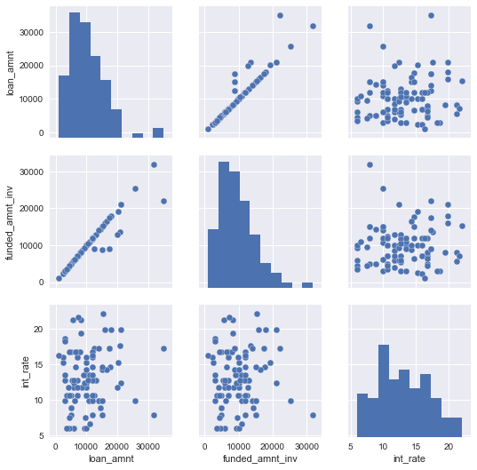

```python
sns.pairplot(sample[['loan_amnt','funded_amnt_inv','int_rate']])
```

```python
from sklearn.ensemble import RandomForestClassifier
from getRiskCol import getRiskCol

file = r'data/cleanerData_necessaryNumerical+imputed_updatedRisk+lessCols.csv'
loans = pd.read_csv(file)

sample = loans.loc[:10000]
labels = sample['risk']
```

## Categorical Values

We are going to turn categorical values into integers and for that we are going to use the One Hot Encoder or equivalent to it, Pandas get_dummies, in order to not add **false information**

```python
from sklearn import preprocessing

sample = pd.get_dummies(sample)
sample
```

|  | loan_amnt | funded_amnt | funded_amnt_inv | int_rate | installment | annual_inc | zip_code | addr_state | dti | delinq_2yrs | ... | purpose_medical | purpose_moving | purpose_other | purpose_renewable_energy | purpose_small_business | purpose_vacation | purpose_wedding | risk_Default | risk_Maybe | risk_NotDefault |
| --- | --- | --- | --- | --- | --- | --- | --- | --- | --- | --- | --- | --- | --- | --- | --- | --- | --- | --- | --- | --- | --- |
| 0 | 5000 | 5000 | 4975.000000 | 10.65 | 162.87 | 24000.00 | 810 | 4 | 27.65 | 0 | ... | 0 | 0 | 0 | 0 | 0 | 0 | 0 | 0 | 0 | 1 |
| 1 | 2500 | 2500 | 2500.000000 | 15.27 | 59.83 | 30000.00 | 296 | 11 | 1.00 | 0 | ... | 0 | 0 | 0 | 0 | 0 | 0 | 0 | 1 | 0 | 0 |
| 2 | 2400 | 2400 | 2400.000000 | 15.96 | 84.33 | 12252.00 | 572 | 15 | 8.72 | 0 | ... | 0 | 0 | 0 | 0 | 1 | 0 | 0 | 0 | 0 | 1 |
| 3 | 10000 | 10000 | 10000.000000 | 13.49 | 339.31 | 49200.00 | 856 | 5 | 20.00 | 0 | ... | 0 | 0 | 1 | 0 | 0 | 0 | 0 | 0 | 0 | 1 |
| 4 | 3000 | 3000 | 3000.000000 | 12.69 | 67.79 | 80000.00 | 909 | 38 | 17.94 | 0 | ... | 0 | 0 | 1 | 0 | 0 | 0 | 0 | 0 | 1 | 0 |
| 5 | 5000 | 5000 | 5000.000000 | 7.90 | 156.46 | 36000.00 | 803 | 4 | 11.20 | 0 | ... | 0 | 0 | 0 | 0 | 0 | 0 | 1 | 0 | 0 | 1 |
| 6 | 7000 | 7000 | 7000.000000 | 15.96 | 170.08 | 47004.00 | 267 | 28 | 23.51 | 0 | ... | 0 | 0 | 0 | 0 | 0 | 0 | 0 | 0 | 1 | 0 |
| 7 | 3000 | 3000 | 3000.000000 | 18.64 | 109.43 | 48000.00 | 839 | 5 | 5.35 | 0 | ... | 0 | 0 | 0 | 0 | 0 | 0 | 0 | 0 | 0 | 1 |
| 8 | 5600 | 5600 | 5600.000000 | 21.28 | 152.39 | 40000.00 | 897 | 5 | 5.55 | 0 | ... | 0 | 0 | 0 | 0 | 1 | 0 | 0 | 1 | 0 | 0 |
| 9 | 5375 | 5375 | 5350.000000 | 12.69 | 121.45 | 15000.00 | 729 | 44 | 18.08 | 0 | ... | 0 | 0 | 1 | 0 | 0 | 0 | 0 | 1 | 0 | 0 |
| 10 | 6500 | 6500 | 6500.000000 | 14.65 | 153.45 | 72000.00 | 804 | 4 | 16.12 | 0 | ... | 0 | 0 | 0 | 0 | 0 | 0 | 0 | 0 | 0 | 1 |
| 11 | 12000 | 12000 | 12000.000000 | 12.69 | 402.54 | 75000.00 | 852 | 5 | 10.78 | 0 | ... | 0 | 0 | 0 | 0 | 0 | 0 | 0 | 0 | 0 | 1 |
| 12 | 9000 | 9000 | 9000.000000 | 13.49 | 305.38 | 30000.00 | 232 | 46 | 10.08 | 0 | ... | 0 | 0 | 0 | 0 | 0 | 0 | 0 | 1 | 0 | 0 |
| 13 | 3000 | 3000 | 3000.000000 | 9.91 | 96.68 | 15000.00 | 572 | 15 | 12.56 | 0 | ... | 0 | 0 | 0 | 0 | 0 | 0 | 0 | 0 | 0 | 1 |
| 14 | 10000 | 10000 | 10000.000000 | 10.65 | 325.74 | 100000.00 | 890 | 5 | 7.06 | 0 | ... | 0 | 0 | 1 | 0 | 0 | 0 | 0 | 1 | 0 | 0 |
| 15 | 1000 | 1000 | 1000.000000 | 16.29 | 35.31 | 28000.00 | 606 | 25 | 20.31 | 0 | ... | 0 | 0 | 0 | 0 | 0 | 0 | 0 | 0 | 0 | 1 |
| 16 | 10000 | 10000 | 10000.000000 | 15.27 | 347.98 | 42000.00 | 860 | 5 | 18.60 | 0 | ... | 0 | 0 | 0 | 0 | 0 | 0 | 0 | 0 | 0 | 1 |
| 17 | 3600 | 3600 | 3600.000000 | 6.03 | 109.57 | 110000.00 | 59 | 7 | 10.52 | 0 | ... | 0 | 0 | 0 | 0 | 0 | 0 | 0 | 0 | 0 | 1 |
| 18 | 6000 | 6000 | 6000.000000 | 11.71 | 198.46 | 84000.00 | 831 | 45 | 18.44 | 2 | ... | 1 | 0 | 0 | 0 | 0 | 0 | 0 | 0 | 0 | 1 |
| 19 | 9200 | 9200 | 9200.000000 | 6.03 | 280.01 | 77385.19 | 860 | 5 | 9.86 | 0 | ... | 0 | 0 | 0 | 0 | 0 | 0 | 0 | 0 | 0 | 1 |
| 20 | 20250 | 20250 | 19142.161077 | 15.27 | 484.63 | 43370.00 | 725 | 44 | 26.53 | 0 | ... | 0 | 0 | 0 | 0 | 0 | 0 | 0 | 0 | 0 | 1 |
| 21 | 21000 | 21000 | 21000.000000 | 12.42 | 701.73 | 105000.00 | 322 | 10 | 13.22 | 0 | ... | 0 | 0 | 0 | 0 | 0 | 0 | 0 | 1 | 0 | 0 |
| 22 | 10000 | 10000 | 10000.000000 | 11.71 | 330.76 | 50000.00 | 754 | 44 | 11.18 | 0 | ... | 0 | 0 | 0 | 0 | 0 | 0 | 0 | 0 | 0 | 1 |
| 23 | 10000 | 10000 | 10000.000000 | 11.71 | 330.76 | 50000.00 | 856 | 5 | 16.01 | 0 | ... | 0 | 0 | 0 | 0 | 0 | 0 | 0 | 0 | 0 | 1 |
| 24 | 6000 | 6000 | 6000.000000 | 11.71 | 198.46 | 76000.00 | 839 | 5 | 2.40 | 0 | ... | 0 | 0 | 0 | 0 | 0 | 0 | 0 | 1 | 0 | 0 |
| 25 | 15000 | 15000 | 15000.000000 | 9.91 | 483.38 | 92000.00 | 571 | 15 | 29.44 | 0 | ... | 0 | 0 | 0 | 0 | 0 | 0 | 0 | 0 | 0 | 1 |
| 26 | 15000 | 15000 | 8725.000000 | 14.27 | 514.64 | 60000.00 | 93 | 35 | 15.22 | 0 | ... | 0 | 0 | 0 | 0 | 0 | 0 | 0 | 1 | 0 | 0 |
| 27 | 5000 | 5000 | 5000.000000 | 16.77 | 123.65 | 50004.00 | 140 | 39 | 13.97 | 3 | ... | 0 | 0 | 1 | 0 | 0 | 0 | 0 | 1 | 0 | 0 |
| 28 | 4000 | 4000 | 4000.000000 | 11.71 | 132.31 | 106000.00 | 313 | 10 | 5.63 | 1 | ... | 0 | 0 | 0 | 0 | 0 | 0 | 0 | 0 | 0 | 1 |
| 29 | 8500 | 8500 | 8500.000000 | 11.71 | 281.15 | 25000.00 | 533 | 24 | 12.19 | 0 | ... | 0 | 0 | 0 | 0 | 0 | 0 | 0 | 0 | 0 | 1 |
| ... | ... | ... | ... | ... | ... | ... | ... | ... | ... | ... | ... | ... | ... | ... | ... | ... | ... | ... | ... | ... | ... |
| 9971 | 4000 | 4000 | 4000.000000 | 11.99 | 88.96 | 26004.00 | 572 | 15 | 24.18 | 0 | ... | 0 | 0 | 0 | 0 | 0 | 0 | 0 | 1 | 0 | 0 |
| 9972 | 35000 | 35000 | 34975.000000 | 11.99 | 1162.34 | 85000.00 | 314 | 10 | 22.76 | 0 | ... | 0 | 0 | 0 | 0 | 0 | 0 | 0 | 0 | 0 | 1 |
| 9973 | 11200 | 11200 | 11200.000000 | 16.89 | 398.70 | 26000.00 | 911 | 38 | 8.08 | 3 | ... | 0 | 0 | 0 | 0 | 0 | 0 | 1 | 1 | 0 | 0 |
| 9974 | 8000 | 8000 | 8000.000000 | 13.49 | 271.45 | 60000.00 | 765 | 6 | 14.92 | 0 | ... | 0 | 0 | 0 | 0 | 0 | 0 | 0 | 0 | 0 | 1 |
| 9975 | 6500 | 6500 | 6500.000000 | 17.49 | 233.34 | 42000.00 | 854 | 5 | 7.91 | 0 | ... | 0 | 0 | 0 | 0 | 1 | 0 | 0 | 0 | 0 | 1 |
| 9976 | 1800 | 1800 | 1800.000000 | 7.49 | 55.99 | 55000.00 | 846 | 5 | 11.30 | 0 | ... | 0 | 0 | 1 | 0 | 0 | 0 | 0 | 0 | 0 | 1 |
| 9977 | 5000 | 5000 | 4750.000000 | 6.99 | 154.37 | 42000.00 | 859 | 5 | 27.86 | 0 | ... | 0 | 0 | 0 | 0 | 0 | 0 | 0 | 0 | 0 | 1 |
| 9978 | 6000 | 6000 | 6000.000000 | 11.99 | 199.26 | 40000.00 | 288 | 11 | 24.06 | 0 | ... | 0 | 0 | 0 | 0 | 0 | 0 | 0 | 0 | 0 | 1 |
| 9979 | 15000 | 15000 | 15000.000000 | 11.99 | 498.15 | 43000.00 | 325 | 10 | 9.27 | 0 | ... | 0 | 0 | 0 | 0 | 0 | 0 | 0 | 0 | 0 | 1 |
| 9980 | 35000 | 35000 | 33594.971546 | 13.49 | 805.17 | 80000.00 | 324 | 10 | 20.54 | 0 | ... | 0 | 0 | 1 | 0 | 0 | 0 | 0 | 0 | 0 | 1 |
| 9981 | 14000 | 14000 | 14000.000000 | 8.49 | 441.89 | 46000.00 | 847 | 5 | 22.67 | 1 | ... | 0 | 0 | 0 | 0 | 0 | 0 | 0 | 0 | 0 | 1 |
| 9982 | 12000 | 12000 | 12000.000000 | 15.23 | 417.34 | 88000.00 | 187 | 9 | 14.85 | 0 | ... | 0 | 0 | 0 | 0 | 0 | 0 | 0 | 1 | 0 | 0 |
| 9983 | 8000 | 8000 | 8000.000000 | 6.99 | 246.99 | 70000.00 | 892 | 5 | 9.19 | 0 | ... | 0 | 0 | 0 | 0 | 1 | 0 | 0 | 0 | 0 | 1 |
| 9984 | 3200 | 3200 | 3200.000000 | 11.99 | 106.28 | 33600.00 | 437 | 36 | 14.68 | 0 | ... | 0 | 0 | 1 | 0 | 0 | 0 | 0 | 0 | 0 | 1 |
| 9985 | 16000 | 16000 | 16000.000000 | 10.99 | 523.75 | 40000.00 | 919 | 48 | 4.53 | 0 | ... | 0 | 0 | 0 | 0 | 1 | 0 | 0 | 0 | 0 | 1 |
| 9986 | 9000 | 9000 | 8975.000000 | 16.49 | 318.60 | 82000.00 | 188 | 9 | 24.78 | 0 | ... | 0 | 0 | 0 | 0 | 0 | 0 | 0 | 0 | 0 | 1 |
| 9987 | 12000 | 12000 | 11750.000000 | 11.99 | 266.88 | 65500.00 | 879 | 5 | 9.36 | 0 | ... | 0 | 0 | 0 | 0 | 0 | 0 | 0 | 0 | 0 | 1 |
| 9988 | 14500 | 14500 | 14500.000000 | 7.49 | 450.98 | 76500.00 | 245 | 50 | 0.00 | 0 | ... | 0 | 0 | 0 | 0 | 0 | 0 | 0 | 1 | 0 | 0 |
| 9989 | 4500 | 4500 | 4250.000000 | 7.49 | 139.96 | 32400.00 | 911 | 38 | 27.63 | 0 | ... | 0 | 0 | 0 | 0 | 0 | 0 | 0 | 0 | 0 | 1 |
| 9990 | 8450 | 8450 | 8450.000000 | 11.49 | 185.80 | 42000.00 | 269 | 28 | 24.71 | 0 | ... | 0 | 0 | 0 | 0 | 0 | 0 | 0 | 1 | 0 | 0 |
| 9991 | 8000 | 8000 | 8000.000000 | 13.49 | 271.45 | 60000.00 | 832 | 34 | 16.06 | 0 | ... | 0 | 0 | 0 | 0 | 0 | 0 | 0 | 0 | 0 | 1 |
| 9992 | 4800 | 4800 | 4800.000000 | 10.59 | 156.22 | 32000.00 | 566 | 15 | 20.21 | 0 | ... | 0 | 0 | 0 | 0 | 0 | 0 | 0 | 0 | 0 | 1 |
| 9993 | 9000 | 9000 | 8750.000000 | 11.49 | 296.75 | 110000.00 | 195 | 21 | 15.36 | 0 | ... | 0 | 0 | 0 | 0 | 0 | 0 | 0 | 1 | 0 | 0 |
| 9994 | 10000 | 10000 | 10000.000000 | 12.99 | 227.48 | 50000.00 | 860 | 5 | 11.66 | 0 | ... | 0 | 0 | 0 | 0 | 1 | 0 | 0 | 0 | 1 | 0 |
| 9995 | 5000 | 5000 | 4750.000000 | 13.49 | 169.66 | 113000.00 | 326 | 10 | 12.96 | 0 | ... | 0 | 0 | 0 | 0 | 0 | 0 | 1 | 0 | 0 | 1 |
| 9996 | 14975 | 14975 | 14975.000000 | 13.49 | 344.50 | 49100.00 | 879 | 5 | 15.71 | 0 | ... | 0 | 0 | 0 | 0 | 0 | 0 | 0 | 0 | 0 | 1 |
| 9997 | 3600 | 3600 | 3600.000000 | 15.62 | 125.90 | 132000.00 | 130 | 35 | 21.62 | 2 | ... | 0 | 0 | 1 | 0 | 0 | 0 | 0 | 0 | 0 | 1 |
| 9998 | 15000 | 15000 | 15000.000000 | 18.39 | 545.23 | 33600.00 | 120 | 35 | 14.25 | 0 | ... | 0 | 0 | 1 | 0 | 0 | 0 | 0 | 0 | 0 | 1 |
| 9999 | 14675 | 14675 | 14650.000000 | 11.49 | 322.67 | 28000.00 | 855 | 5 | 23.10 | 0 | ... | 0 | 0 | 0 | 0 | 0 | 0 | 0 | 1 | 0 | 0 |
| 10000 | 1000 | 1000 | 1000.000000 | 10.99 | 32.74 | 30000.00 | 895 | 5 | 23.12 | 0 | ... | 0 | 0 | 0 | 0 | 0 | 0 | 0 | 0 | 0 | 1 |

10001 rows × 111 columns

## Scaling Data

In order to analize the data more properly we need to scale the data. We are going to use **Standar Scaler** to do that.

```python
from sklearn.preprocessing import StandardScaler

scaler = StandardScaler()
scaler.fit(sample)

scaled_sample = scaler.transform(sample)
```

## Dimensionality Reduction

We added some columns in order to deal with the categorical data, but the dimension of the data matrix increased by alot. Luckily we learned about **P**rincipal **C**omponent **A**nalisys, so now we can reduce the dimensionality of the data. However we still need to check which of the original features are most importat, so we need to take into account the **mean** and **variance** of each one.

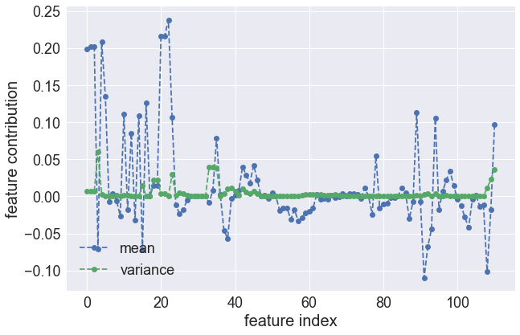

```python
from sklearn.decomposition import PCA

n_comp = 2
pca = PCA(n_components=n_comp, svd_solver='auto')
fit = pca.fit(scaled_sample)
pca_data = pca.transform(scaled_sample)
pca_inv_data = pca.inverse_transform(np.eye(n_comp))

fig = plt.figure(figsize=(10, 6.5))
plt.plot(pca_inv_data.mean(axis=0), '--o', label = 'mean')
plt.plot(np.square(pca_inv_data.std(axis=0)), '--o', label = 'variance')
plt.legend(loc='lower right')
plt.ylabel('feature contribution', fontsize=20);
plt.xlabel('feature index', fontsize=20);
plt.tick_params(axis='both', which='major', labelsize=18);
plt.tick_params(axis='both', which='minor', labelsize=12);
plt.legend(loc='lower left', fontsize=18)
```

```python
i = np.identity(scaled_sample.shape[1])  # identity matrix

coef = pca.transform(i)
pd.DataFrame(coef[80:-1], columns=['PC-1', 'PC-2'], index=sample.columns[80:-1])
```

|  | PC-1 | PC-2 |
| --- | --- | --- |
| emp_length_3 years | -0.009796 | -0.010131 |
| emp_length_4 years | -0.007613 | -0.009882 |
| emp_length_5 years | -0.004258 | 0.001669 |
| emp_length_6 years | -0.002077 | -0.000316 |
| emp_length_7 years | 0.003786 | -0.001992 |
| emp_length_8 years | 0.008249 | 0.015016 |
| emp_length_9 years | 0.000825 | 0.007788 |
| emp_length_< 1 year | -0.027229 | -0.033004 |
| emp_length_n/a | -0.019103 | 0.004669 |
| home_ownership_MORTGAGE | 0.069957 | 0.157101 |
| home_ownership_OWN | -0.012860 | -0.001604 |
| home_ownership_RENT | -0.063143 | -0.156187 |
| verification_status_Not Verified | -0.129559 | -0.005220 |
| verification_status_Source Verified | -0.046014 | -0.041756 |
| verification_status_Verified | 0.165964 | 0.044450 |
| purpose_car | -0.036688 | 0.001278 |
| purpose_credit_card | -0.007442 | 0.020704 |
| purpose_debt_consolidation | 0.064184 | -0.019288 |
| purpose_home_improvement | 0.004559 | 0.062531 |
| purpose_house | 0.015041 | 0.013342 |
| purpose_major_purchase | -0.032642 | 0.025031 |
| purpose_medical | -0.020921 | -0.004779 |
| purpose_moving | -0.029555 | -0.026778 |
| purpose_other | -0.040480 | -0.043752 |
| purpose_renewable_energy | -0.013326 | 0.004957 |
| purpose_small_business | 0.014885 | -0.012139 |
| purpose_vacation | -0.026089 | -0.000321 |
| purpose_wedding | -0.015634 | -0.007371 |
| risk_Default | 0.004049 | -0.206574 |
| risk_Maybe | 0.133242 | -0.170014 |

# Testing Classifiers

Now that we have a reduced data sample with the most important features, we can start training different classifiers and compare them

```python
from sklearn.ensemble import RandomForestClassifier
from sklearn.model_selection import train_test_split
from sklearn.model_selection import cross_val_score

X_train, X_test, y_train, y_test = train_test_split(reduced_sample, labels, test_size=0.4, random_state=0)

pred= {}
score_test= {}
```

## Random Forest

```
Train MSE Mean Score: 0.9985

Mean CV Score:  0.969003879864
Standard Deviation: 0.00768204085241

Test MSE Mean Score: 0.978005498625

Normalized confusion matrix
```

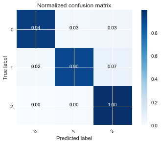

```python
clf = RandomForestClassifier(n_estimators=10, criterion='gini',
                             max_depth=None, bootstrap=True, oob_score=False, n_jobs=2)

clf.fit(X_train, y_train)
clf.score(X_train, y_train)

print "Train MSE Mean Score: %s\n"%clf.score(X_train, y_train)

cv_scores = cross_val_score(clf, X_train, y_train, cv=5)

print "Mean CV Score: ", np.mean(cv_scores)
print "Standard Deviation: %s\n"% np.std(cv_scores)

key= 'RF'
pred[key] = clf.predict(X_test)
score_test[key]= clf.score(X_test, y_test)
expected = y_test

print "Test MSE Mean Score: %s\n"%score_test[key]

plot_confusion_matrix(metrics.confusion_matrix(expected, pred[key]), classes=range(3), normalize=True,
                      title='Normalized confusion matrix')
```

#### Full Sample Result

[figure not shown]

## Support Vector Machine

```
Train MSE Mean Score: 1.0

Mean CV Score:  0.750666736227
Standard Deviation: 0.000243004007596

Test MSE Mean Score: 0.745813546613

Normalized confusion matrix
```

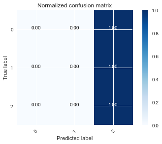

```python
from sklearn import svm

clf = svm.SVC(decision_function_shape='ovo')

clf.fit(X_train, y_train)
clf.score(X_train, y_train)

print "Train MSE Mean Score: %s\n"%clf.score(X_train, y_train)

cv_scores = cross_val_score(clf, X_train, y_train, cv=5)

print "Mean CV Score: ", np.mean(cv_scores)
print "Standard Deviation: %s\n"% np.std(cv_scores)

key= 'SVM'
pred[key] = clf.predict(X_test)
score_test[key]= clf.score(X_test, y_test)
expected = y_test

print "Test MSE Mean Score: %s\n"%score_test[key]

plot_confusion_matrix(metrics.confusion_matrix(expected, pred[key]), classes=range(3), normalize=True,
                      title='Normalized confusion matrix')
```

#### Full sample didn't run ..

## K Nearest Neighbor

```
Train MSE Mean Score: 0.831

Mean CV Score:  0.820832589236
Standard Deviation: 0.00246776339501

Test MSE Mean Score: 0.824043989003

Normalized confusion matrix
```

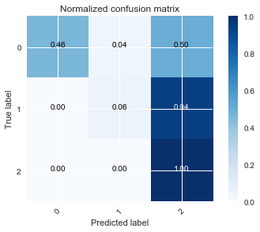

```python
from sklearn.neighbors import KNeighborsClassifier

clf = KNeighborsClassifier(n_neighbors=30)
clf.fit(X_train, y_train)
clf.score(X_train, y_train)

print "Train MSE Mean Score: %s\n"%clf.score(X_train, y_train)

cv_scores = cross_val_score(clf, X_train, y_train, cv=5)

print "Mean CV Score: ", np.mean(cv_scores)
print "Standard Deviation: %s\n"% np.std(cv_scores)

key= 'KNN'
pred[key] = clf.predict(X_test)
score_test[key]= clf.score(X_test, y_test)
expected = y_test

print "Test MSE Mean Score: %s\n"%score_test[key]

plot_confusion_matrix(metrics.confusion_matrix(expected, pred[key]), classes=range(3), normalize=True,
                      title='Normalized confusion matrix')
```

#### Full Sample Result

[figure not shown]

## Loan Outcome

```python
def loanApprovalStatus(riskArr, int_rate, funded_amount, datalabel):
    # assume daily compounding. 60 months term.
    # defaulting: rejected.
    # risky & nonrisky: all accepted - high risk with the former.

    riskArr= np.array(riskArr)
    int_rate= np.array(int_rate)
    funded_amount= np.array(funded_amount)

    tot= len(riskArr)
    profit= np.zeros(tot)

    int_rate= int_rate/100.

    loanTerm= np.zeros(tot)+60.
    ##
    default= np.where(riskArr=='Default')[0]
    profit[default]= -700

    # assume monthly compounding
    n= 365.

    # calculate profit
    notdefault= np.where(riskArr=='NotDefault')[0]
    nYears= loanTerm[notdefault]/12.
    profit[notdefault]= funded_amount[notdefault]*(1.+((int_rate[notdefault])/n))**(n*nYears)-funded_amount[notdefault]

    risky= np.where(riskArr=='Maybe')[0]
    nYears= (loanTerm[risky]+6.)/12.   # assume risky would take 6months extra?
    profit[risky]= funded_amount[risky]*(1+((int_rate[risky])/n))**(n*nYears)-funded_amount[risky]

    # profit percent
    profitPercent= profit/funded_amount

    # loan approval? accept everything thats not 100% defaulting.
    loanApproval= np.zeros(tot)+1
    loanApproval[default]= 0.

    # plot histogram: profit %
    bins= 20
    alpha= 0.5
    fontsize= 14
    histtype= 'bar'
    plt.hist(profitPercent[risky], label= 'maybe', alpha= alpha, bins= bins, histtype=histtype)
    plt.hist(profitPercent[notdefault], label= 'not default', alpha= alpha, bins= bins, histtype=histtype)
    plt.xlabel('profit (% funded)', fontsize= fontsize)
    plt.title('%s: Approval rate (%%): %s'%(datalabel, 100.*(1.-float(len(default))/tot)), fontsize= fontsize)
    plt.legend(fontsize= fontsize)
    plt.gcf().set_size_inches(12,6)

    ax= plt.axes()
    ax.tick_params(axis='x', labelsize=fontsize)
    ax.tick_params(axis='y', labelsize=fontsize)

    plt.show()
```

#### Sub-sample run

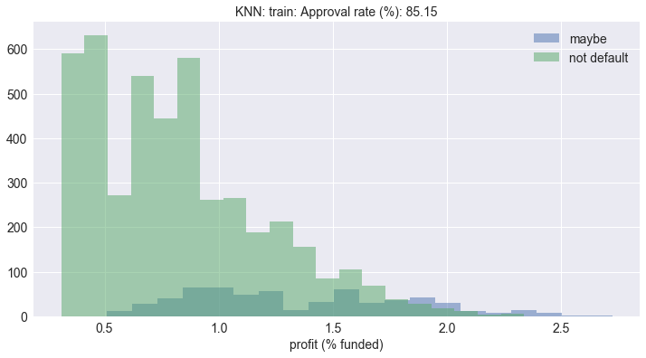

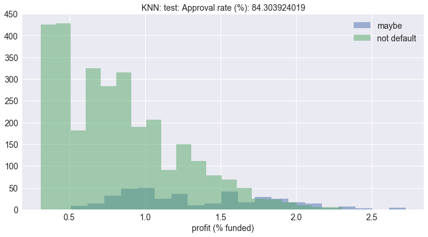

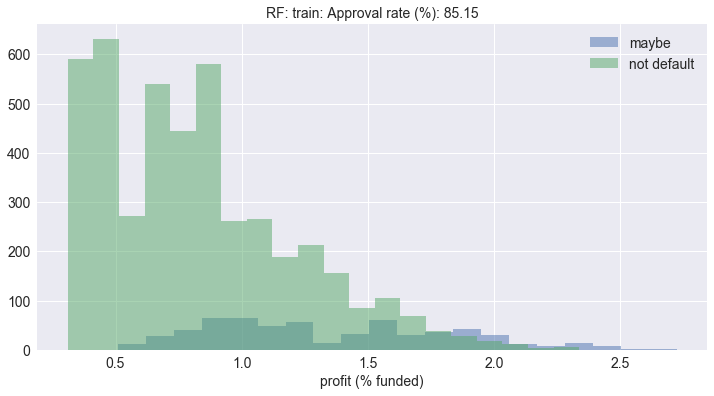

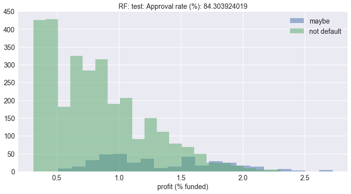

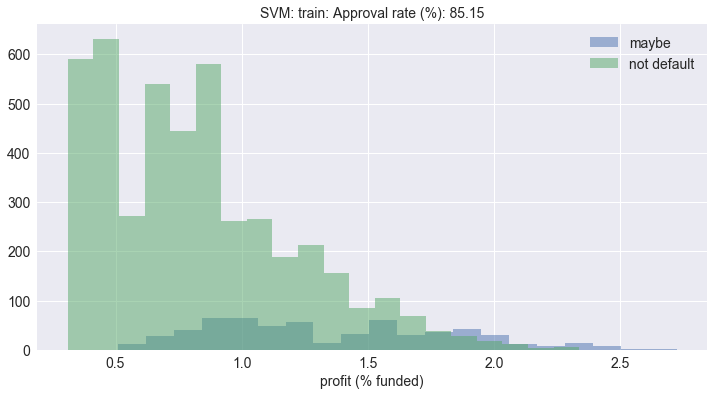

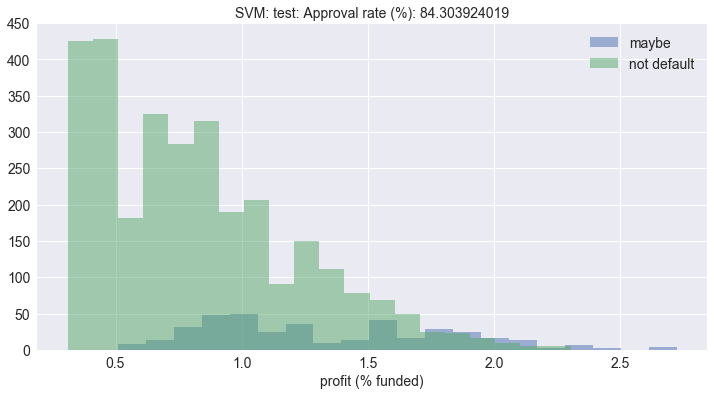

```python
for alg in pred.keys():
    ## train
    data_all= X_train
    riskArr= y_train
    label= '%s: train'%alg

    loanApproval= loanApprovalStatus(riskArr= riskArr,
                                     int_rate= data_all['int_rate'],
                                     funded_amount= data_all['funded_amnt'],
                                    datalabel= label)
    # test
    data_all= X_test
    riskArr= y_test
    label= '%s: test'%alg

    loanApproval= loanApprovalStatus(riskArr= riskArr,
                                     int_rate= data_all['int_rate'],
                                     funded_amount= data_all['funded_amnt'],
                                    datalabel= label)

    print '******** ******** ******** ******** ******** ******** ********'
```

## Summary

### Goal: Predict Loan Outcomes

#### Roadblocks:

- Missing Data v1: rejected applications stats missing
  - Couldn't help.
  - Used secondary info to answer our question: 1) Predict Risk 2) Account for profits 3) Decide on loan outcomes
- Missing Data v2: features from approved loan application missing
  - Removal of features that were missing for 90+% data
  - Imputation for the rest
- String classification for various features + class
  - Enumeration, e.g. for zipcodes
  - One-hot encoding for the rest

#### Main Techniques

- Data clean up; imputation
- PCA for feature extraction
- Classifiers: RF, SVM, KNN

#### Need to do

- Get SVM to work on full sample.
- More thorough cross-validation.
- More involved feature selection?
- Think more about how to evaluate the loan outcomes.